# Spatial Trends in R

## Methods

- Non-geostatistical (IDW, Trend analysis - regression…)
- Geostatistical (Kriging)

## Trend analysis

A spatial trend model is defined as

\[Z(x_i) = \mu(x_i) + \epsilon(x_i)\] where the expected mean \(\mu(x_i)\) is a function of location \(x_i = (x, y)\); \(\epsilon(x_i)\) is a zero-mean error.

## Stationarity

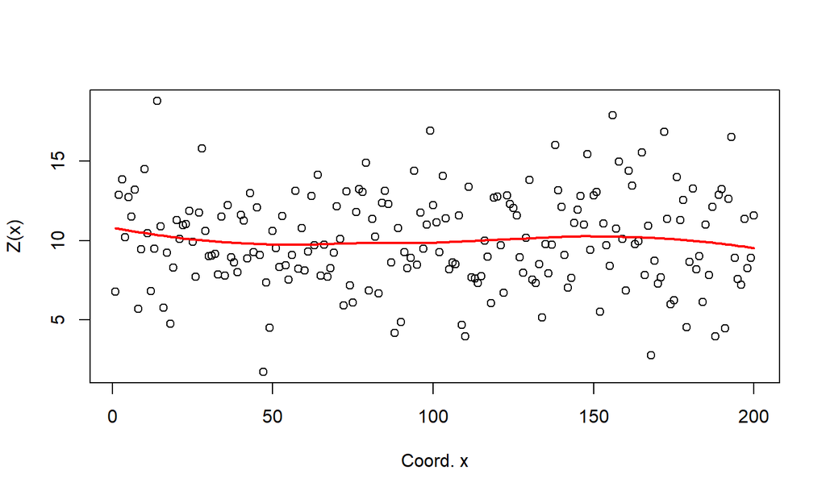

## Example

Load the data

```r
library(rgdal) ; library(sp) ; library(raster)
abund = readOGR('shp_lessons/abundance_n.shp', verbose = F)
colnames(attr(abund, 'coords')) = c('x', 'y')
abund
```

```
## class       : SpatialPointsDataFrame
## features    : 672
## extent      : 490270.8, 491857.2, 5803253, 5803528  (xmin, xmax, ymin, ymax)
## crs         : +proj=utm +zone=34 +datum=WGS84 +units=m +no_defs
## variables   : 1
## names       : abundance
## min values  :         1
## max values  :         5
```

## Example

Trend across coordinates x or y

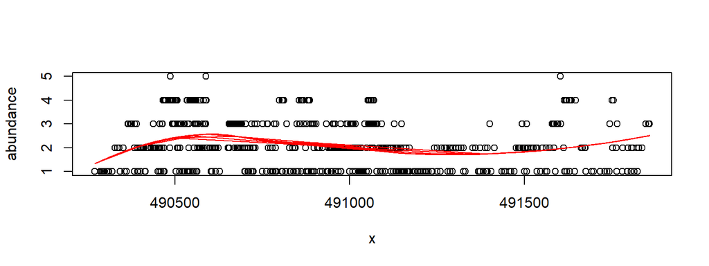

```r
plot(abundance ~ x, data = abund)
smoo = loess(abundance ~ x, data = abund)
lines(predict(smoo) ~ x, abund, col = 'red')
```

## Parametric trend surfaces

- \(g[\mu(x_i)] = \beta_0\)
- \(g[\mu(x_i)] = \beta_0 + covariates\)
- \(g[\mu(x_i)] = \beta_0 + \beta_1x + \beta_2y\)
- \(g[\mu(x_i)] = \beta_0 + \beta_1x + \beta_2y + \beta_3x^2 + \beta_4y^2 + \beta_5xy\)
- \(g[\mu(x_i)] = \beta_0 + h(x, y)\)

where \(g[\cdot]\) is called *link function* (e.g. log, for Poisson counts); \(h(\cdot)\) is a smooth function (e.g. splines)

## Comparisons of models

Akaike’s Information Criterion (the lower the better):

\[AIC = -2\log L(\mu) + 2k\] \(L(\mu)\) is the likelihood function of the fitted model, \(k\) is the number of parameters (\(\beta\)).

For nested models, a *LRT - Likelihood Ratio Test* can be applied

\[R_L = 2[\log L(\hat{\mu}) - \log L(\beta_0)] \sim \chi^2_{\nu}\]

## Fitting models

```r
model_1 = lm(abundance ~ 1, data = abund)
coef(model_1)
```

```
## (Intercept)
##    2.151786
```

```r
model_2 = lm(abundance ~ I(x^2) + I(y^2) + I(x*y) + x + y, data = abund)
coef(model_2)
```

```
##   (Intercept)        I(x^2)        I(y^2)      I(x * y)             x
## -5.573114e+03  2.827027e-07  2.194543e-09 -4.790017e-08            NA
##             y
##            NA
```

## AIC

```r
AIC(model_1, model_2)
```

```
##         df      AIC
## model_1  2 1882.993
## model_2  5 1861.839
```

## LRT

```r
anova(model_1, model_2, test = 'LR') # for nested models only
```

```
## Analysis of Variance Table
##
## Model 1: abundance ~ 1
## Model 2: abundance ~ I(x^2) + I(y^2) + I(x * y) + x + y
##   Res.Df    RSS Df Sum of Sq  Pr(>Chi)
## 1    671 644.52
## 2    668 618.99  3    25.525 4.523e-06 ***
## ---
## Signif. codes:  0 '***' 0.001 '**' 0.01 '*' 0.05 '.' 0.1 ' ' 1
```

## Prediction grid

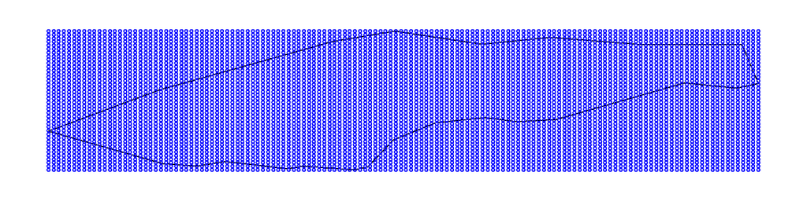

```r
vistula = readOGR('shp_lessons/vistula_islands.shp', verbose = F)
north = subset(vistula, Name == 'northern_island')
ext = extent(north)[]
gr = expand.grid(x = seq(ext[1], ext[2], length = 140),
                 y = seq(ext[3], ext[4], length = 40))
coordinates(gr) = c('x', 'y')  # SpatialPoints
gridded(gr) = TRUE             # SpatialPixel object
crs(gr) <- crs(north)
par(mar = c(1,1,1,1)); plot(north)
points(gr, cex = 0.5, col = 'blue')
```

## Prediction map

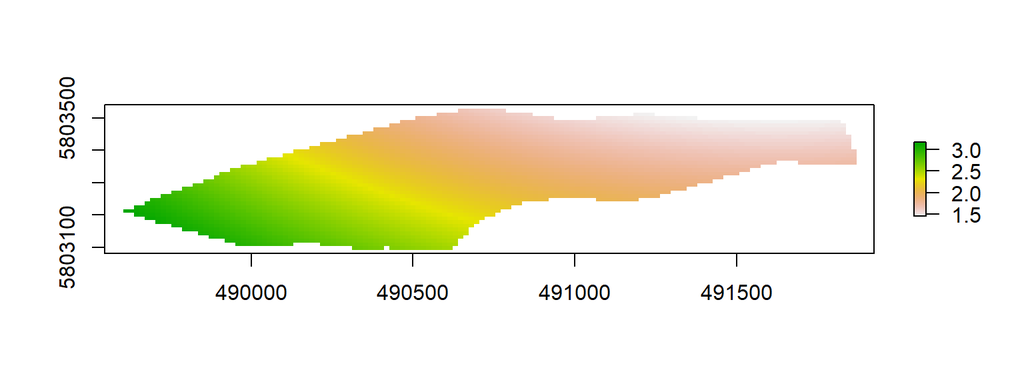

```r
pred = predict(model_2, newdata = gr, se.fit = TRUE)
r = raster(gr)
r$pred = pred$fit
plot( mask(r$pred, north) )
```

## Prediction Standard Errors

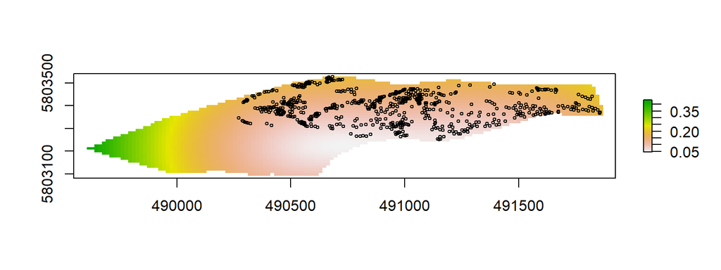

```r
r$se = pred$se.fit
plot( mask(r$se, north) )
points(abund, cex = 0.5)
```

## Check residuals

```r
library(spdep)
gd = pointDistance(coordinates(abund), lonlat = FALSE)
wl = mat2listw(gd < 50)
moran.test(residuals(model_2, type = 'pearson'), listw = wl)
```

```
##
##  Moran I test under randomisation
##
## data:  residuals(model_2, type = "pearson")
## weights: wl
##
## Moran I statistic standard deviate = 32.018, p-value < 2.2e-16
## alternative hypothesis: greater
## sample estimates:
## Moran I statistic       Expectation          Variance
##      0.3391963283     -0.0014903130      0.0001132189
```

## Further trend surfaces

- \(g[\mu(x_i)] = \beta_0 + S(x_i)\)
- \(g[\mu(x_i)] = \beta_0 + S(x_i) + N_i\)

where \(S(x_i)\) is a spatial gaussian *random effect* with mean zero, variance \(\sigma^2\) and correlation \(\rho(d)\); \(N_i\) is a non-spatial random effect with variance \(\tau^2\) (nugget)

## Generalized least squares

\[\hat{\beta} = (X'\Sigma^{-1}X)^{-1}X'\Sigma^{-1}z\]

\(\Sigma\) is the residual covariance matrix, which allows to model, for example, correlations of the form

\[\rho(d) = (1-\tau^2)\exp(-d/\phi)\]

## Fitting a model with correlated errors

```r
library(nlme)
model_3 = gls(abundance ~ x+y, data = abund,
              correlation = corExp(form = ~ x + y, nugget=TRUE))
summary(model_3)
```

```
## Generalized least squares fit by REML
##   Model: abundance ~ x + y
##   Data: abund
##        AIC      BIC    logLik
##   1031.831 1058.865 -509.9153
##
## Correlation Structure: Exponential spatial correlation
##  Formula: ~x + y
##  Parameter estimate(s):
##        range       nugget
## 3.680545e+01 2.207941e-10
##
## Coefficients:
##                  Value Std.Error    t-value p-value
## (Intercept) -2868.0059  9406.122 -0.3049084  0.7605
## x              -0.0001     0.000 -0.1888160  0.8503
## y               0.0005     0.002  0.3078257  0.7583
##
##  Correlation:
##   (Intr) x
## x  0.023
## y -1.000 -0.038
##
## Standardized residuals:
##        Min         Q1        Med         Q3        Max
## -0.8353143 -0.6984185  0.3711768  1.4679763  3.7921104
##
## Residual standard error: 0.8901804
## Degrees of freedom: 672 total; 669 residual
```

## Dealing with correlated errors: AIC

```r
AIC(model_1, model_2, model_3)
```

```
##         df      AIC
## model_1  2 1882.993
## model_2  5 1861.839
## model_3  6 1031.831
```

## Dealing with correlated errors: correlation

```r
res_3 = residuals(model_3, type = 'normalized')
moran.test(res_3, listw = wl)
```

```
##
##  Moran I test under randomisation
##
## data:  res_3
## weights: wl
##
## Moran I statistic standard deviate = 3.7606, p-value = 8.475e-05
## alternative hypothesis: greater
## sample estimates:
## Moran I statistic       Expectation          Variance
##      0.0384499739     -0.0014903130      0.0001127998
```

## References

- Bivand et al. (2008). Applied spatial data analysis with R (Vol. 747248717, pp. 237-268). New York: Springer. URL https://link.springer.com/book/10.1007/978-1-4614-7618-4
- Diggle, P.; Ribeiro Junior, P. J. (2007) Model-based Geostatistics. Springer, New York, NY. https://link.springer.com/book/10.1007/978-0-387-48536-2